# Lecture 6: Applications 1 - Simulation Studies

In the previous class we:

- Introduced boolean types and if/else statments
- Introduced a type of structure with indendented code

In this class we will:

- Talk about basic manipulation of lists
- Introduce "For" Loops and examples of key algorithms

## I. Import Libraries

```python
# the "numPy" library is used for mathematical operations
# the "matplotlib" library is for generating graphs
# the "pandas" library is for manipualting datasets

import numpy as np
import matplotlib.pyplot as plt
import pandas as pd
```

## II. Visualizing Random Variables

Consider a sample with $n$ observations

$ X = \begin{pmatrix} X_1 \\ X_2 \\ \vdots \\ X_n \end{pmatrix}.$

We can simulate from different distributions

```python
# Set Sample size
# These produce several common distributions
# A normam with "loc" and standard deviation "5"
# A chi-square with "df" degrees of freedom
# A uniform with values between -3 and 5

n = 10000

vec_normal  = np.random.normal(loc = 5, scale = 5, size = n)
vec_chisqr  = np.random.chisquare(df = 1, size = n)
vec_unif    = np.random.uniform(low = -3,high = 5, size = n)
```

The sample average is defined as

$ \bar{X} = \frac{1}{n}\sum_i X_i $

```python
# Let's print of each of the above random variables

print(vec_normal.mean())
print(vec_chisqr.mean())
print(vec_unif.mean())
```

```
5.003975367282813
1.028420376418503
1.045261834220084
```

Multiple plots in a row (subplot)

- The normal has more of a bell shape
- The uniform is a rectangular shape

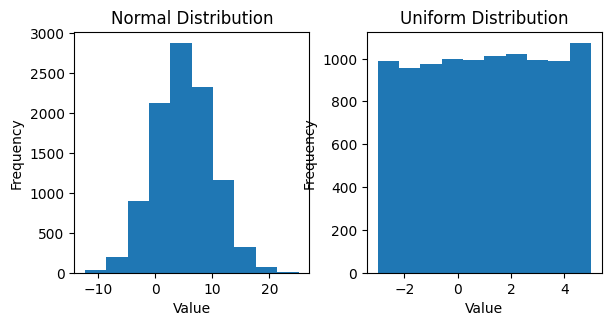

```python
#------------------------ Setting up subplots----------------------------------#
# Create a plot with 1 row, 2 columns
# You will create a list of subfigures "list_subfig"
# You can choose whichever name you like
# The option "figsize" indicates the (width,height) of the graph
fig, list_subfig = plt.subplots(1, 2,figsize = (6,3))

# The tight layout option ensures that the axes are not overlapping
plt.tight_layout()


# First Figure
list_subfig[0].hist(x = vec_normal)
list_subfig[0].set_title("Normal Distribution")
list_subfig[0].set_xlabel("Value")
list_subfig[0].set_ylabel("Frequency")

# Second Figure
list_subfig[1].hist(x = vec_unif)
list_subfig[1].set_title("Uniform Distribution")
list_subfig[1].set_xlabel("Value")
list_subfig[1].set_ylabel("Frequency")

# Note:
# Use the set_title() function for the title of subfigures
# Similarly, use "set_xlabel()" and "set_ylabel()"
```

Try it yourself!

- Do a version with three plots in the same row
- What happens if you remove the "plt.tight_layout()" command?
- What happens if you change the "figsize"?

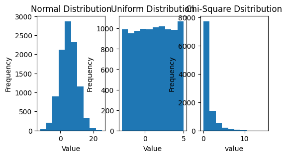

```python
# Write down your solution

fig, list_subfig = plt.subplots(1, 3,figsize = (6,3))

#first figure
list_subfig[0].hist(x = vec_normal)
list_subfig[0].set_title("Normal Distribution")
list_subfig[0].set_xlabel("Value")
list_subfig[0].set_ylabel("Frequency")

# Second Figure
list_subfig[1].hist(x = vec_unif)
list_subfig[1].set_title("Uniform Distribution")
list_subfig[1].set_xlabel("Value")
list_subfig[1].set_ylabel("Frequency")

#third figure
list_subfig[2].hist(x = vec_chisqr)
list_subfig[2].set_title("Chi-Square Dsitribution")
list_subfig[2].set_xlabel("value")
list_subfig[2].set_ylabel("Frequency")
```

## III. Singe Loops

Simple sequences: $[0,1,2,...,n-1]$

```python
# Use "list(range(n))" to create a list from 0 to (n-1).

n= 10
list_zero_ten = list(range(n))
print(list_zero_ten)
```

```
[0, 1, 2, 3, 4, 5, 6, 7, 8, 9]
```

What happens to $\bar{X}$ if we draw different samples?

```python
vec_xbar = [None, None, None, None]
sample_size = 100

vec_unif = np.random.uniform(low=-2, high=2, size=sample_size)
vec_xbar[0] = vec_unif.mean()

vec_unif = np.random.uniform (low=-2, high=2, size=sample_size)
vec_xbar[1] = vec_unif.mean()

vec_unif = np. random.uniform(low=-2, high=2, size=sample_size)
vec_xbar[2] = vec_unif.mean()

vec_unif = np. random.uniform(low=-2, high=2, size=sample_size)
vec_xbar[3] = vec_unif.mean()
```

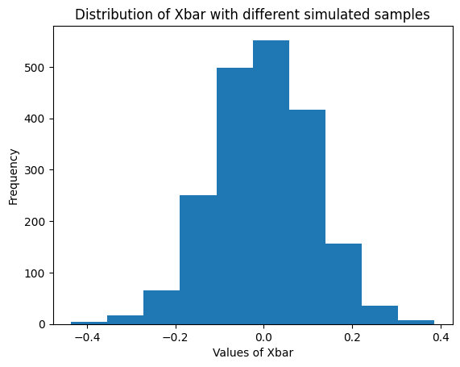

```python
# We will draw random sample "num_simulations" times
# Each time we will create a random vector of size "sample_size"
# In this example we will generate values from a uniform between -2 and 2.

num_simulations = 2000
sample_size     = 100

vec_xbar = [None] * num_simulations

for iteration in range(num_simulations):
    vec_unif  = np.random.uniform(low = -2, high=2, size = sample_size)
    vec_xbar[iteration] = vec_unif.mean()

plt.hist(vec_xbar)
plt.title("Distribution of Xbar with different simulated samples")
plt.ylabel("Frequency")
plt.xlabel("Values of Xbar")
plt.show()
```

## III. Nested Loops

What happens to $\bar{X}$ with different $n$?

- The Central Limit Theorem makes a prediction!
- It says that the distribution will have a bell shape with higher $n$.

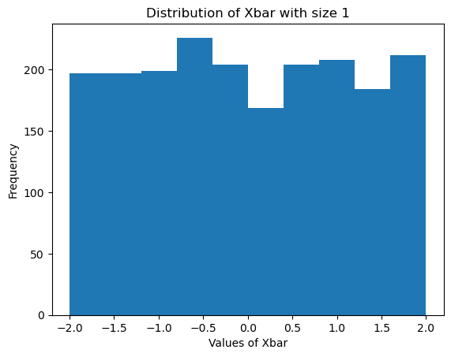

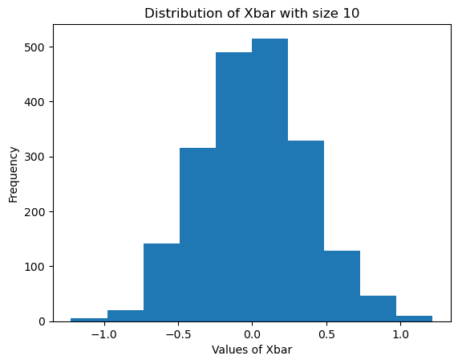

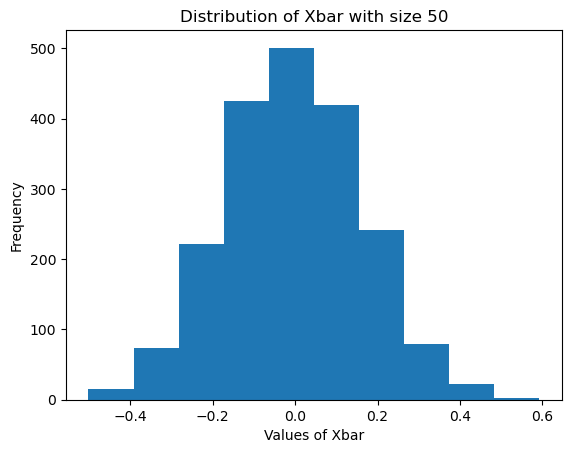

```python
# One way is to write this with repeated code chunks
# We just repeat the code that we had above, with different sample sizes
# Each time will start the process of generating new data from scratch.

num_simulations = 2000

# Simulate with sample size one
sample_size = 1
vec_xbar = [None] * num_simulations
for iteration in range(num_simulations):
    vec_unif  = np.random.uniform(low = -2, high=2, size = sample_size)
    vec_xbar[iteration] = vec_unif.mean()
plt.hist(vec_xbar)
plt.title("Distribution of Xbar with size 1")
plt.ylabel("Frequency")
plt.xlabel("Values of Xbar")
plt.show()

# Simulate with sample size 10
sample_size = 10
vec_xbar = [None] * num_simulations
for iteration in range(num_simulations):
    vec_unif  = np.random.uniform(low = -2, high=2, size = sample_size)
    vec_xbar[iteration] = vec_unif.mean()
plt.hist(vec_xbar)
plt.title("Distribution of Xbar with size 10")
plt.ylabel("Frequency")
plt.xlabel("Values of Xbar")
plt.show()

# Simulate with sample size 50
sample_size = 50
vec_xbar = [None] * num_simulations
for iteration in range(num_simulations):
    vec_unif  = np.random.uniform(low = -2, high=2, size = sample_size)
    vec_xbar[iteration] = vec_unif.mean()
plt.hist(vec_xbar)
plt.title("Distribution of Xbar with size 50")
plt.ylabel("Frequency")
plt.xlabel("Values of Xbar")
plt.show()
```

Nested Loops

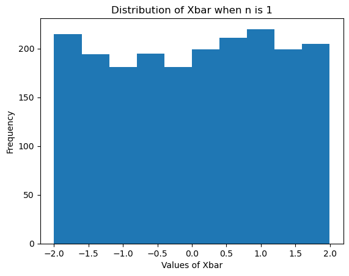

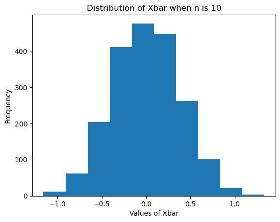

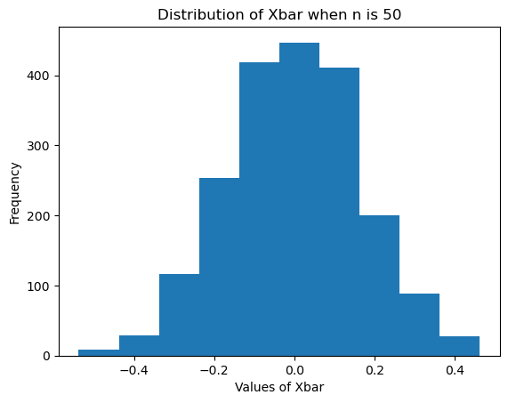

```python
# To evaluate different sample size which just have to write a for-loop within
# another for-loop

num_simulations = 2000
sample_size_list = [1,10,50]

for sample_size in sample_size_list:

    # The following command a vector null values, of length "num_simulations"
    vec_xbar = [None] * num_simulations

    for iteration in range(num_simulations):
            vec_unif  = np.random.uniform(low = -2, high=2, size = sample_size)
            vec_xbar[iteration] = vec_unif.mean()
    plt.hist(vec_xbar)
    plt.title("Distribution of Xbar when n is " + str(sample_size))
    plt.ylabel("Frequency")
    plt.xlabel("Values of Xbar")
    plt.show()
```

Try it yourself!

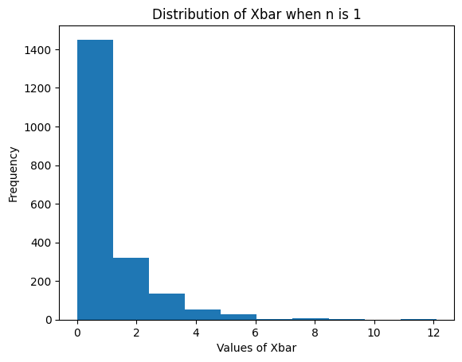

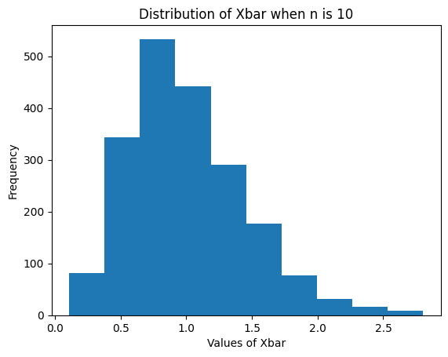

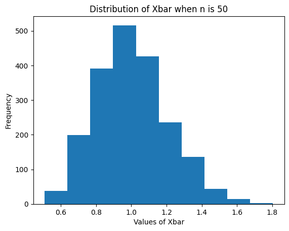

```python
# Write your own solution
num_simulations = 2000
sample_size_list = [1,10,50]

for sample_size in sample_size_list:

    # The following command a vector null values, of length "num_simulations"
    vec_xbar = [None] * num_simulations

    for iteration in range(num_simulations):
            vec_unif  = np.random.chisquare(df = 1, size = sample_size)
            vec_xbar[iteration] = vec_unif.mean()
    plt.hist(vec_xbar)
    plt.title("Distribution of Xbar when n is " + str(sample_size))
    plt.ylabel("Frequency")
    plt.xlabel("Values of Xbar")
    plt.show()
```

Try it yourself!

- Write code that puts all the figures in the same row

```python
# Write your own solution
```

## IV. Loops + If/else

The proportion of "True" statements in a boolean list

```python
# Define a list with True/False values
list_boolean = [True,False,True,False,False]
np.mean(list_boolean)
```

```
0.4
```

Let "sample_stdv" be the sample standard deviation of $X_i$.

```python
# Parameters of a normal random variable
n                 = 10000
population_mean   = 2
population_stdv   = 5

# Create random variable and produce summary statistics
X           = np.random.normal(loc = 2,scale = 5,size = n)
Xbar        = X.mean()
sample_stdv = X.std()

# Check that the sample and standard deviation are close to their
# population values
print(Xbar)
print(sample_stdv)
```

```
2.0124667183105562
5.027506440619916
```

A 95% normal confidence interval is defined by $\ldots$

- lower_bound = $\bar{X} -1.96 \times \frac{\text{sample\_stdv}}{\sqrt{n}}$.
- upper_bound = $\bar{X} + 1.96 \times \frac{\text{sample\_stdv}}{\sqrt{n}}$.

```python
# Compute new variables for the upper and lower bound

lower_bound = Xbar - 1.96*(sample_stdv / np.sqrt(n))
upper_bound = Xbar + 1.96*(sample_stdv / np.sqrt(n))
```

Try it yourself! Write an if/else that checks whether

lower_bound $\quad \le \quad $ population_mean $\quad \le \quad$ upper_bound

```python
# Write your own code
```

Try it yourself! Test whether this is a 95% confidence interval

Procedure:

- Create a variable called "num_simulations" with value 1000
- Create the simulation parameters "n", "population_mean", "populations_stdv".
- Create an empty vector called "list_test_confidenceinterval".
- Create a loop. At each iteration:
  - Create a vector of normal random variables of size "n".
  - Create a variable "test_confidenceinterval", which tests:

    lower_bound $\quad \le \quad $ population_mean $\quad \le \quad$ upper_bound
  - Append "test_confidenceinterval" to the above list
- Compute the mean of "list_test_confidenceinterval"

Note: The final result should be close to 95%.

```python
# Write your own  code:
```